# Bullshit

## Описание исследования

[Ссылка на оригинальную работу](http://journals.plos.org/plosone/article?id=10.1371/journal.pone.0153419)  
Определение: Булщит — бессодержательное, нелогичное или явно противоречащее элементарным научным знаниям утверждение.Например,

- Скрытый смысл трансформирует беспрецедентную абстрактную красоту

Испытуемые: 196 граждан Америки (43.4% женщин, средний возраст 36.4 лет), набранные на Amazon Mechanical Turk.

Задание для испытуемых

1. Оценить глубокомысленность утверждений по шкале от 1 (“абсолютно не глубокое”) до 5 (“очень глубокое”)
2. Оценить степень симпатии к трём кандидатам в президенты США от демократической и трём — от республиканской партий по шкале от 1 (“очень несимпатичен”) до 5 (“очень симпатичен”)
3. Оценить степень консервативности собственных политических взглядов по семибалльной шкале Лайкерта.

Часть утверждений, оцениваемых респондентами, — была булщитом, часть — относительно редкими поговорками.

Прочитаем данные и определим вспомогательные функции:

```r
d <- read.csv("./bullshit.csv")

addtrend <- function(x, y){
  y <- y[order(x)]
  x <- sort(x)
  smoothed <- loess.smooth(x, y)
  with(smoothed, lines(x, y, col = "blue", lwd=3))
}

PlotBulshitVs <- function(y.name) {
  x <- d$MeanBullshit
  y <- d[, y.name]
  rm <- which(is.na(x) | is.na(y))
  if (length(rm) > 0) {
    x <- x[-rm]
    y <- y[-rm]
  }
  p.val <- cor.test(x,y,method="spearman")$p.value
  par(mar=c(4.3,4.3,2.1,0.1) + .1, mfrow=c(1,1))
  plot(x, jitter(y, amount=0.1), pch=19, col=rgb(255,0,0,100,maxColorValue = 255),
       main=paste("Spearman p-value = ",  p.val),
       xlab="Bullshit Receptivity", ylab=y.name, lwd=3,  cex=1.8, cex.lab=1.8, cex.axis=1.8)
  m <- lm(y~x)
  lines(c(0,6), m$coefficients[1] + m$coefficients[2] * c(0,6), lwd=3)
  addtrend(x,y)
}
```

## Анализ

- Для каждого испытуемого вычислялась средняя склонность считать булщит глубокомысленным.
- Вычислялась корреляция Спирмена между итоговым признаком, консервативностью политических взглядов и степенями симпатии к кандидатам.
- Для проверки значимости отличия корреляции от нуля использовался критерий Стьюдента.

Основные результаты, которые в этой статье были получены - обнаружена значимая положительная корреляция между тягой к булщиту и

- симпатией к Теду Крузу, Марку Рубио и Дональду Трампу - кандидатам республиканской партии
- степенью консерватизма

## Критика

Визуализируем находки авторов статьи.

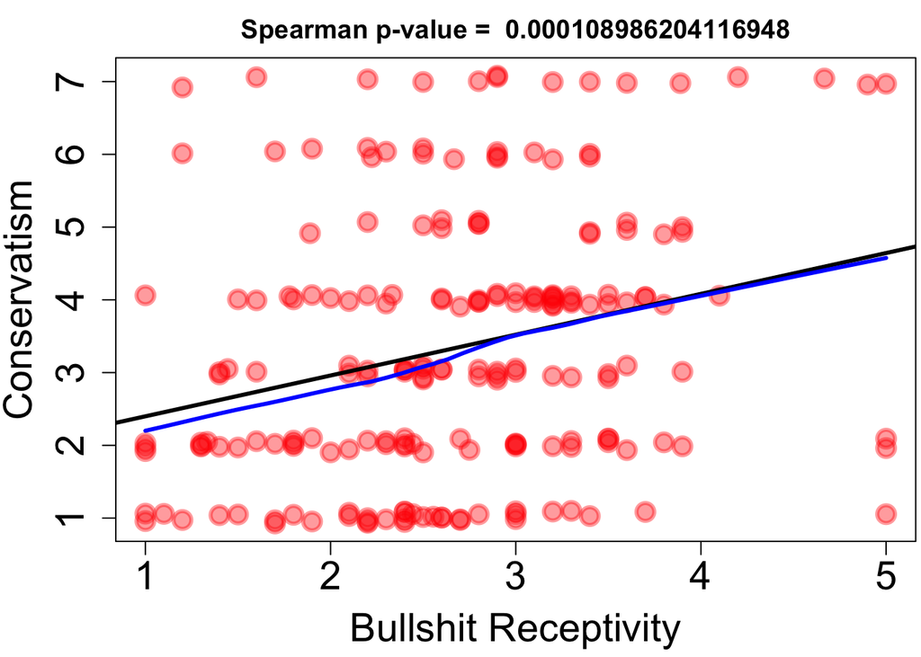

```r
PlotBulshitVs("Conservatism")
```

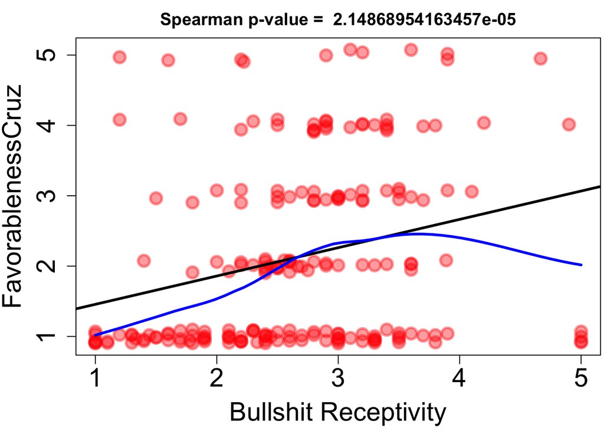

```r
PlotBulshitVs("FavorablenessCruz")
```

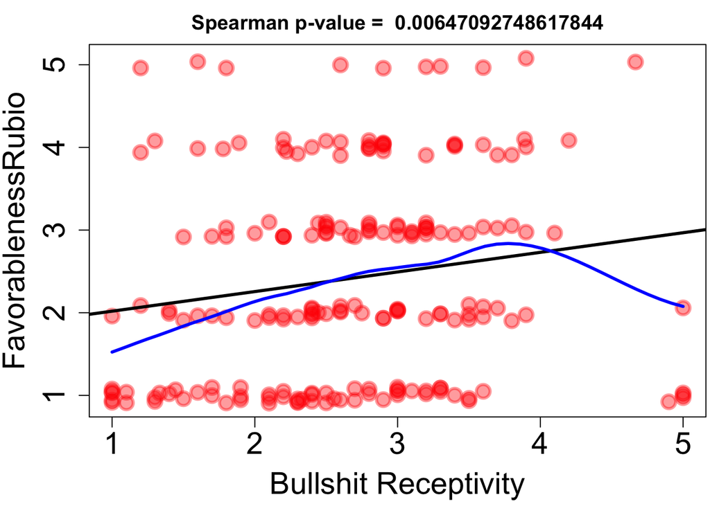

```r
PlotBulshitVs("FavorablenessRubio")
```

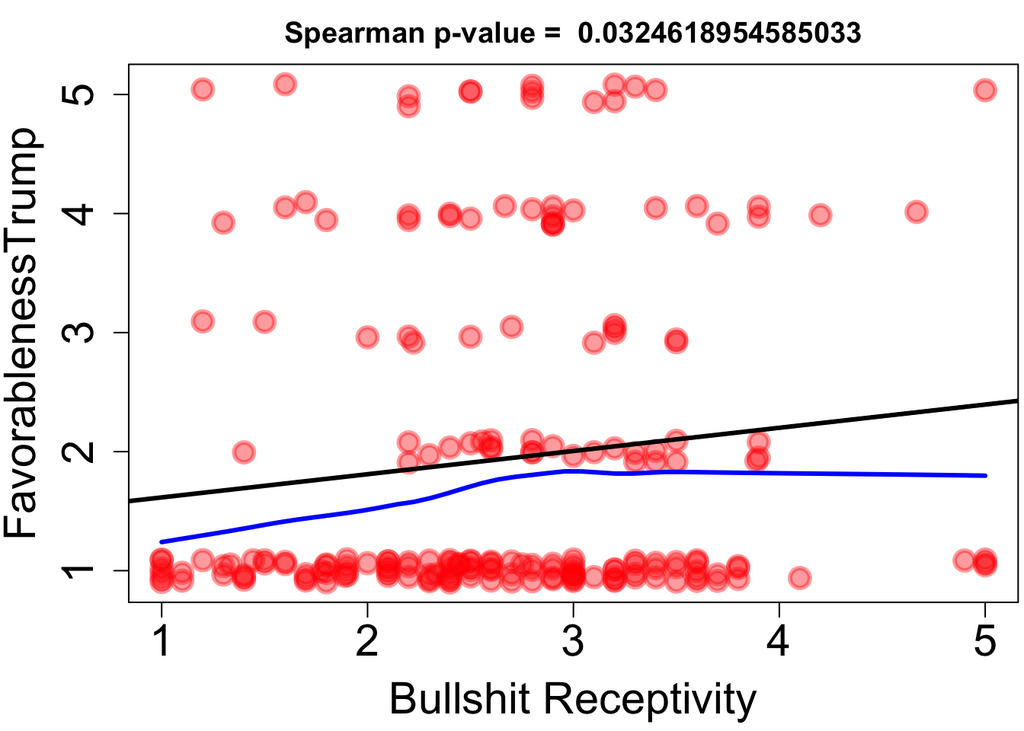

```r
PlotBulshitVs("FavorablenessTrump")
```

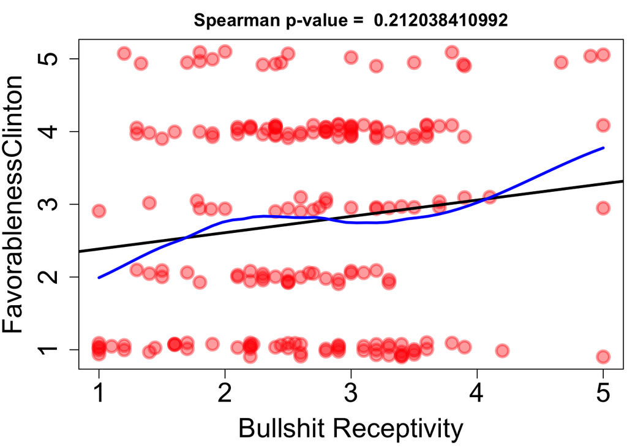

```r
PlotBulshitVs("FavorablenessClinton")
```

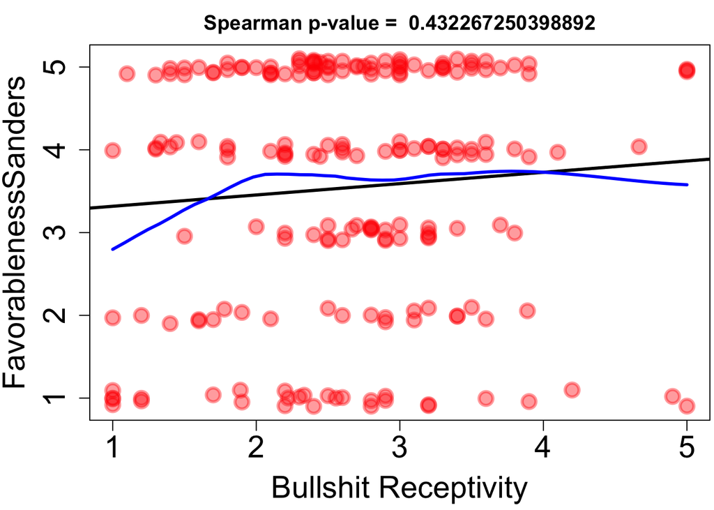

```r
PlotBulshitVs("FavorablenessSanders")
```

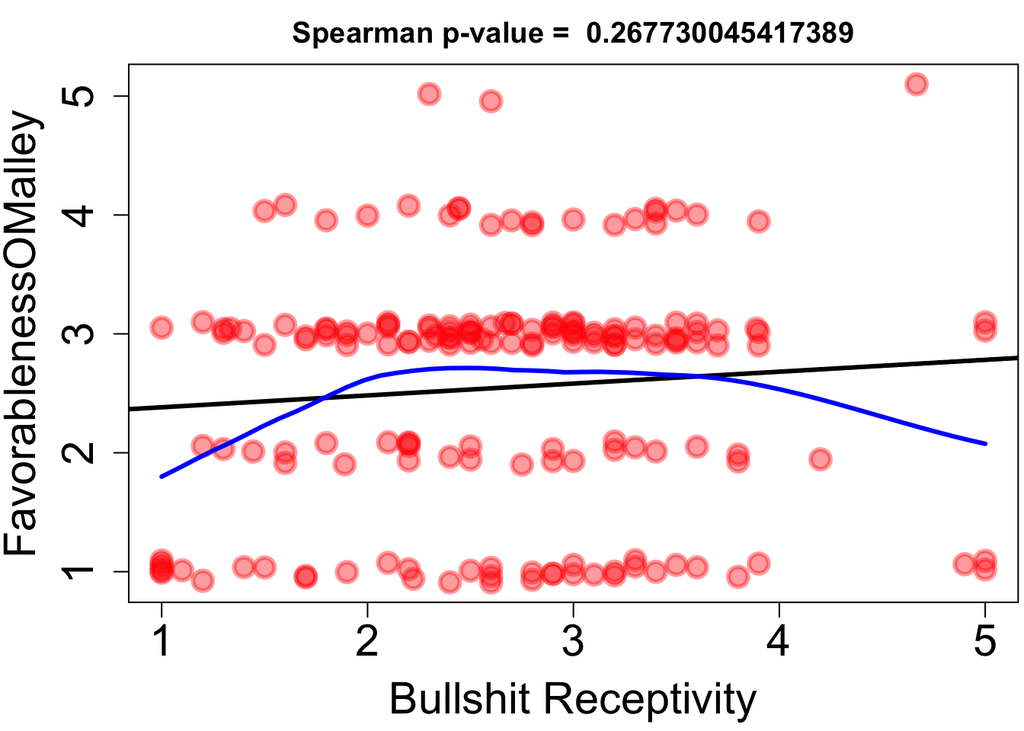

```r
PlotBulshitVs("FavorablenessOMalley")
```

Учитывая, что Cruz, Rubio, Trump относятся к республиканской партии (которую поддерживат люди, консервативных взглядов), найдите как можно больше проблем этого исследования и аргументов против находок в этой статье.

```r
# type your code here
```